# Texto para Discussão - Padronização da extração de dados do SIM-SUS para mortes no trânsito

2024-10-08

## Apresentando o problema

O SIM-SUS (Brasil, 2024) é a principal base de dados consolidada referente a mortes no trânsito no Brasil. Não há consenso, porém, sobre quais códigos CID-10 (WHO, 2019) devem ser selecionados para compor a estimativa, de modo que diferentes números são apresentados conforme o método utilizado.

O objetivo deste **Texto para discussão** é propor uma forma de padronizar como tais números são gerados. Ele parte de algumas fontes da própria Organização Mundial de Saúde (WHO, 2020, 2022) para a seleção das CID-10 para, em seguida, considerar os argumentos presentes na literatura científica de que uma redistribuição de alguns códigos é necessária para mitigar uma provável subnotificação de registros de sinistros no trânsito nas categorias adequadas, devido à marcação em categorias mais genéricas (Bhalla *et al.*, 2023; Bhalla; Harrison, 2015; Brasil, 2019; WHO, 2020).

Os resultados serão apresentados por ano e lado a lado para ambos os métodos: primeiro, a partir da seleção das categorias listadas em WHO (2020) e, segundo, com a redistribuição proposta no mesmo documento. O tratamento dos dados é feito no software R (R Core Team, 2024) e os trechos de script utilizados são apresentados ao longo das seções.

Este documento está organizado da seguinte forma:

1. Como baixar a base de dados do SIM-SUS;
2. Como filtrar as CID-10 relacionadas a mortes no trânsito, conforme WHO (2020);
3. Discussão sobre a redistribuição dos dados de categorias genéricas;
4. Redistribuição dos dados de intenção indeterminada, também conforme WHO (2020);
5. Resultados e discussão;
6. Referências utilizadas.

## Como baixar as bases do SIM-SUS

### Usando o R

No R, o seguinte código vai baixa todos os arquivos de base de dados .dbc do SIM-SUS para os anos de 2011 a 2023.

```r
# Importar bibliotecas necessárias
library('tidyverse')
library('tidylog')
library('read.dbc')

# Pasta para armazenamento dos dados
sim_sus_folder <- sprintf('%s/dados', getwd())
dir.create(sim_sus_folder, recursive = TRUE, showWarnings = FALSE)

# Definir anos de início e de fim
ano_inicial <- 11; ano_final <- 23
base_url <- 'ftp://ftp.datasus.gov.br/dissemin/publicos/SIM'
# Puxar as bases de dados
for (ano in seq(ano_inicial, ano_final)) {
  # Baixar somente se arquivo ainda não existir na pasta
  dbc_file <- sprintf('%s/DOEXT%s.DBC', sim_sus_folder, ano)
  if (!file.exists(dbc_file)) {
    url <- sprintf('%s/CID10/DOFET/DOEXT%s.DBC', base_url, ano)
    result <- try({ download.file(url, dbc_file)} , silent = TRUE)
    # Se arquivo consolidado não existir, tentar versão preliminar
    if (class(result) == "try-error") {
      url <- sprintf('/PRELIM/DOFET/DOEXT%s.DBC', base_url, ano)
      download.file(url, dbc_file)
    }
  }
}
```

### De forma manual

Na [página de downloads do DATASUS](https://datasus.saude.gov.br/transferencia-de-arquivos/), selecionar:

1. Fonte: SIM - Sistema de Informações de Mortalidade;
2. Modalidade: Dados;
3. Tipo de Arquivo: DOEXT - Declarações de Óbitos por Causas Externas - 1979 a 2022;
4. Ano: no teclado, use shift + click para selecionar todos os anos a partir de 2011;
5. UF: BR

Ao clicar no botão “Enviar”, uma listagem similar à ilustrada a seguir aparecerá. Clique no link “Download” abaixo da tabela e espere até que um arquivo .zip seja gerado, como no rodapé da imagem - o processo deve demorar pouco menos de um minuto. Clique nele para fazer o download das bases de dados.

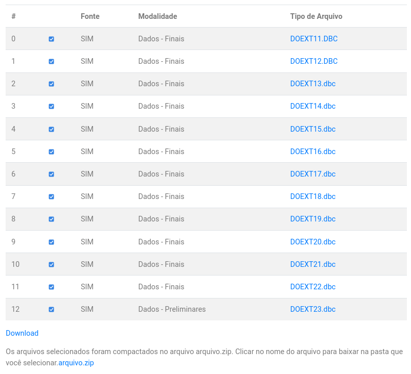

## Como filtrar sinistros de trânsito na base do SIM-SUS

O código a seguir lê todos os anos da base do SIM-SUS como um único dataframe, seleciona as colunas de DTOBITO e CAUSABAS e cria uma coluna de ano a partir de DTOBITO.

```r
# Ler arquivos originais compactados em .dbc como dataframes
sim_sus <- list.files(path       = sim_sus_folder,
                      pattern    = 'DOEXT...DBC',
                      recursive  = FALSE,
                      full.names = TRUE)

sim_sus <- sim_sus %>% map_df(read.dbc) %>% as_tibble()

# Selecionar colunas de interesse para ocorrências de trânsito
sim_sus <- sim_sus %>% select(DTOBITO, CAUSABAS)
# Para comparativos com o município de São Paulo
# sim_sus <- sim_sus %>% select(DTOBITO, CODMUNOCOR, CAUSABAS) %>% filter(CODMUNOCOR == '355030')

# Criar coluna de ano da morte
sim_sus <- sim_sus %>% mutate(ANOOBITO = str_sub(.$DTOBITO, -4), .before = 'DTOBITO')
```

As causas básicas da CID-10 a serem consideradas como sinistros de trânsito são definidas no documento **WHO methods and data sources for country-level causes of death 2000-2019 and 2000-2021** [Métodos e fontes de dados da OMS para as causas de morte a nível nacional 2000-2019 e 2000-2021] (WHO, 2020, 2024). Para países em que a CID-10 possui quatro caracteres, como é o caso do Brasil, os códigos a serem filtrados são os seguintes, tendo como base WHO (2020):

```
V01-V04 (.1-.9), V06 (.1-.9), V09 (.2-.3), V10- V14 (.3-.9), V15-V19 (.4-.9), V20-V28 (.3-.9), V29- V79 (.4-.9), V80 (.3-.5), V81.1, V82 (.1, .8-.9), V83-V86 (.0-.3), V87 (.0-.9), V89 (.2-.3, .9), V99, Y85.0
```

O script em R para executar este filtro e agrupar os resultados por ano é apresentado a seguir.

```r
# ------------------------------------------------------------------------------
# Funções
# ------------------------------------------------------------------------------

# Filtra dataframe e agrupa resultados por uma variável (por padrão, ANOOBITO)
agrupar <- function(df, filter_expr, group_var = expr(ANOOBITO), n_col = 'n') {
  df %>%
    filter(!!filter_expr) %>%
    group_by(!!group_var) %>%
    tally() %>%
    ungroup() %>%
    rename(!!n_col := n)
}
# f_expr <- expr(str_starts(CAUSABAS, 'Y32'))
# agrupar(sim_sus, f_expr, n_col = 'y32')


# ------------------------------------------------------------------------------
# Mortes no trânsito
# ------------------------------------------------------------------------------

# WHO methods and data sources for country-level causes of death 2000-2019
# https://www.who.int/docs/default-source/gho-documents/global-health-estimates/ghe2019_cod_methods.pdf
# V01-V04 (.1-.9), V06 (.1-.9), V09 (.2-.3), V10- V14 (.3-.9), V15-V19 (.4-.9),
# V20-V28 (.3-.9), V29- V79 (.4-.9), V80 (.3-.5), V81.1, V82 (.1, .8-.9),
# V83-V86 (.0-.3), V87 (.0-.9), V89 (.2-.3, .9), V99, Y85.0

# Road injuries
f_expr <- expr(
  str_starts(CAUSABAS, 'V0[12346][1-9]') | str_starts(CAUSABAS, 'V09[2-3]') |
    str_starts(CAUSABAS, 'V1[0-4][3-9]') | str_starts(CAUSABAS, 'V1[5-9][4-9]') |
    str_starts(CAUSABAS, 'V2[0-8][3-9]') | str_starts(CAUSABAS, 'V29[4-9]') |
    str_starts(CAUSABAS, 'V[3-7][0-9][4-9]') |
    str_starts(CAUSABAS, 'V80[3-5]') | str_starts(CAUSABAS, 'V8[12]1') |
    str_starts(CAUSABAS, 'V82[8-9]') | str_starts(CAUSABAS, 'V8[3-6][0-3]') |
    str_starts(CAUSABAS, 'V87[0-9]') | str_starts(CAUSABAS, 'V89[239]') |
    str_starts(CAUSABAS, 'V99') | str_starts(CAUSABAS, 'Y850')
)
road_injuries <- agrupar(sim_sus, f_expr, n_col = 'road_injuries')
```

Tabela 1. Sinistros de trânsito extraídos conforme WHO (2020), sem redistribuição dos códigos de intenção indeterminada.

```r
road_injuries
```

| Ano de óbito | Sinistros de trânsito |
| --- | --- |
| 2011 | 41.756 |
| 2012 | 43.152 |
| 2013 | 40.826 |
| 2014 | 42.221 |
| 2015 | 37.321 |
| 2016 | 36.165 |
| 2017 | 34.310 |
| 2018 | 31.549 |
| 2019 | 30.836 |
| 2020 | 31.644 |
| 2021 | 32.981 |
| 2022 | 32.989 |
| 2023 | 32.883 |

Utilizados desta forma, sem a redistribuição de outros códigos CID-10, o números são os mesmos contidos na plataforma **WHO Mortality Database - Road Traffic Accidents** [Base de Mortalidade da OMS - Sinistros de Trânsito] (WHO, 2022), que possui dados para o Brasil até o ano de 2020.

É importante mencionar que a listagem de códigos presentes no rodapé e na seção “[About](https://platform.who.int/mortality/about/list-of-causes-and-corresponding-icd-10-codes)” [Sobre] da base de dados WHO Mortality Database possui uma ligeira diferença com relação à em WHO (2020). Especificamente, a redação da seleção começa com “**V01-V04**, V06 (.1-.9)…”, em vez de “**V01-V04 (.1-.9)**, V06 (.1-.9)…”, como descrito em WHO (2020). Trata-se, provavelmente, de um erro de redação, uma vez os números são iguais à filtragem de V01-V04 (.1-.9) e não somente de V01-V04.

## Discussão sobre a redistribuição dos dados de categorias genéricas

Conforme comentado ao início do texto, há uma discussão presente na literatura que argumenta que utilizar somente os dados das categorias previamente selecionadas resulta em um número subestimado de mortes no trânsito (Bhalla *et al.*, 2023; Bhalla; Harrison, 2015; Brasil, 2019; WHO, 2020). Um resumo de como cada publicação sugere a seleção dos códigos a serem considerados e quais CID-10 genéricas devem ser redisribuídas proporcionalmente para as mais específicas é apresentado a seguir.

[output not shown]

Em Brasil (2019), são utilizados dos métodos distintos para ler os dados do SIM-SUS. O primeiro aparece no **Capítulo 2 - Evolução e principais causas da mortalidade na infância e componentes nas regiões brasileiras entre 2010 e 2016** e faz um recorte dentro da causas externas relacionadas aos chamados “acidentes de transporte terrestres” na CID-10. Neste capítulo, não há redistribuição dos números vindos de outras categorias da CID-10. O segundo método está presente no **Capítulo 5 - Mortalidade por lesões decorrentes do trânsito no Brasil, 2000 a 2016** e seleciona todos os códigos dos “acidentes de transporte terrestres” (V01 a V89) para, em seguida, reclassificar óbitos com causa básica inespecífica (V87 a V89, V99 e Y32 a Y34) proporcionalmente entre os grupos específicos. Esta é a mesma abordagem presente em Aquino; Antunes; Morais Neto (2020).

As publicações do IPEA - Instituto de Pesquisa Econômica Aplicada tendem a utilizar a seleção V01 a V89 (Carvalho, 2020; Carvalho; Guedes, 2023; Ferreira, 2020), exceto o **Atlas da Violência - Violência no Trânsito** (IPEA, 2023), que pega todos os códigos de acidentes de transporte, V01 a V99.

Bhalla *et al.* (2023) seleciona boa parte dos códigos de acidentes de transporte terrestres, o código Y85.0 - Sequelas de acidente com veículo motorizado [*Sequelae of motor-vehicle accident*] e propõe redistribuir os códigos referentes às causas de morte “não especificadas” - seja pelo veículo, seja pela intenção, seja pela própria causa da morte. O texto, porém, deixa implícita uma discussão presente em Bhalla; Harrison (2015) sobre quais desses códigos se refere à porção de mortes “em trânsito” ou “fora do trânsito”, que é importante.

### Sinistros de trânsito na CID-10

A imagem a seguir ilustra o **Capítulo XX – Causas externas de morbidade e de mortalidade** (à esquerda) e a categoria de **Pedestres feridos em acidente de transporte (V01-V09)** (à direita), que faz parte dos acidentes de transporte terrestres na CID-10.

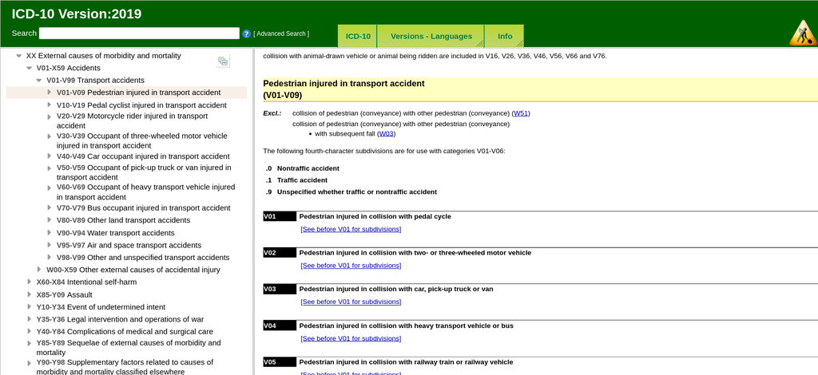

A imagem também mostra uma subdivisão dentro das causas básicas que é relevante para o cômputo de mortes no trânsito. Ela é específica para países cuja marcação da CID-10 possui uma quarta letra, como é o caso do Brasil.

| Quarta letra da CID-10 | Subdivisão |
| --- | --- |
| .0 | Acidente fora de trânsito [*Nontraffic accident*] |
| .1 | Acidente de trânsito [*Traffic accident*] |
| .9 | Não especificado se de trânsito ou fora dele [*Unspecified whether traffic or nontraffic accident*] |

Ou seja, ao considerar todos os códigos de acidentes terrestres (V01-V89) o que se está observando não é exatamente as “mortes no trânsito”, mas especificamente as “mortes resultantes de fazer qualquer deslocamento terrestre”, que podem ter ocorrido fora da via pública. As definições da seção de [**Acidentes de Transporte**](https://icd.who.int/browse10/2019/en#/V01-V99) (definições A a D), traduzidas a seguir de forma livre, ajudam a ilustrar este ponto:

1. Um **acidente de transporte** (V01–V99) é qualquer acidente que envolva um dispositivo projetado principalmente para, ou que esteja sendo usado no momento principalmente para, transportar pessoas ou mercadorias de um lugar a outro.
2. Uma **via pública** [via de tráfego] ou rua é toda a largura entre os limites da propriedade (ou outros limites) de terras abertas ao público como questão de direito ou costume, para fins de deslocamento de pessoas ou bens de um lugar a outro. O leito carroçável [*roadway*] é a parte da via pública projetada, melhorada e comumente usada para o tráfego de veículos.
3. Um **acidente de trânsito é qualquer acidente envolvendo veículos que ocorre na via pública** [ou seja, que se origina na via, termina na via, ou envolve um veículo parcialmente na via]. Assume-se que um acidente de veículo ocorreu na via pública, a menos que um outro local seja especificado, exceto no caso de acidentes que envolvam apenas veículos motorizados fora da estrada, os quais são classificados como acidentes não de tráfego, a menos que o contrário seja afirmado.
4. Um **acidente não de trânsito é qualquer acidente de veículo que ocorre totalmente em qualquer lugar que não seja uma via pública**.

Tal distinção entre sinistros de trânsito ou fora dele está presente na seleção dos códigos adotada em WHO (2020) e WHO (2024) (Anexo A), que especificamente remove todos os códigos cuja atribuição se refere ao “*nontraffic accident*” [acidente fora de trânsito]. Quando há dúvidas se uma causa de morte é em trânsito ou não, o que na CID-10 aparece como “não especificado” [*unspecified*], as seleções de WHO (2020) e WHO (2024) as incluem - na prática, considerando-as como em trânsito.

Finalmente, WHO (2020) e WHO (2024) propõem a redistribuição proporcional dos códigos de **intenção indeterminada**, Y10-Y34 e Y87.2. Os primeiros se referem aos “Eventos com intenção não determinada” [*Event of undetermined intent*] (Y10-Y34), definidos como “eventos em que as informações disponíveis são insuficientes para permitir que uma autoridade médica ou legal faça a distinção entre acidente, automutilação e agressão”. Já o código Y87.2 engloba “Sequelas de eventos de intenção indeterminada” [*Sequelae of events of undetermined intent*].

As distribuições são citadas nos dois documentos tendo como base Mathers; Lopez; Murray (2006), que descrevem o método da seguinte forma: “*As mortes atribuídas a códigos para lesões cuja intenção não foi determinada, se acidental ou intencional ((…) códigos ICD-10 Y10–Y34 e Y872), são aquelas em que a pessoa que certifica a causa da morte não determinou se as lesões foram não intencionais ou intencionais, por exemplo, um resultado de lesão auto infligida ou agressão. (…) Para reduzir o viés na estimativa de mortes devido a lesões não intencionais e intencionais, as mortes codificadas como intenção indeterminada foram redistribuídas pro rata por idade e sexo para as categorias do estudo GBD [Global Burden of Disease] de lesão intencional e não intencional*”.

## Redistribuição dos dados de intenção indeterminada

Os códigos de intenção indeterminada, Y10-Y34 e Y87.2, fazem parte das causas externas de morbidade e de mortalidade, assim como os números de sinistros de trânsito previamente extraídos e apresentados na Tabela 1. De forma a fazer uma redistribuição proporcional conforme WHO (2020) e WHO (2024), os passos sugeridos são:

1. Extrair os valores totais de causas externas (V01-Y89, exceto X41-X42, X44, X45);
2. Calcular o novo valor de causas externas, excluindo os relacionados aos códigos de intenção não determinada (Y10-Y34, Y87.2);
3. Calcular o proporcional relativo de sinistros de trânsito frente ao novo total das causas externas;
4. Alocar proporcionalmente os valores dos códigos Y10-Y34, Y87.2 para os sinistros de trânsito.

O código em R para o passo-a-passo descrito acima e seus resultados são apresentados a seguir.

```r
# ------------------------------------------------------------------------------
# Redistribuição dos códigos de eventos e sequelas - intenção indeterminada (1)
# ------------------------------------------------------------------------------

# WHO methods and data sources for country-level causes of death 2000-2019
# https://www.who.int/docs/default-source/gho-documents/global-health-estimates/ghe2019_cod_methods.pdf
# Injury deaths where the intent is not determined (Y10-Y34, Y87.2) are
# distributed proportionately to all causes below the group level for injuries.

# Isolar causas externas - V01-Y89 (minus X41-X42, X44, X45)
f_expr <- expr(str_starts(CAUSABAS, '[VWXY]') & !str_starts(CAUSABAS, 'X4[1245]'))
external_causes <- agrupar(sim_sus, f_expr, n_col = 'external_causes')

# Códigos Y10-Y34, Y87.2 fazem parte das external causes, dentro das quais
# também estão as road injuries, calculadas anteriormente. Isolar somente
# códigos Y10-Y34, Y87.2 - undetermined intent
f_expr <- expr(str_starts(CAUSABAS, 'Y[12]') |
               str_starts(CAUSABAS, 'Y3[0-4]') |
               str_starts(CAUSABAS, 'Y872'))
undefined_intent <- agrupar(sim_sus, f_expr, n_col = 'undefined_intent')

# Calcular novo valor para external causes sem undetermined intent
external_causes_new <-
  external_causes %>%
  left_join(undefined_intent, by = 'ANOOBITO') %>%
  mutate(external_causes_new = external_causes - undefined_intent)

# Calcular ajuste de road injuries
road_injuries_adj <-
  external_causes_new %>%
  # Fazer cálculos proporcionais para ajustar road injuries
  left_join(road_injuries, by = 'ANOOBITO') %>%
  # Qual a proporção das road injuries frente ao total de external causes?
  mutate(prop_road_inj = road_injuries / external_causes_new,
         # Qual a proporção de undetermined intent que deverá ser alocada
         # para road injuries?
         und_int_alloc = round(undefined_intent * prop_road_inj),
         # Fazer a alocação em uma nova coluna, new_road_inj
         new_road_inj  = road_injuries + und_int_alloc,
         # Calcular percentual de acréscimo frente aos valores anteriores de
         # road injury
         road_inj_incr = (new_road_inj - road_injuries) / road_injuries * 100)
```

Tabela 2. Sinistros de trânsito ajustados com redistribuição dos códigos de intenção indeterminada Y10-Y34, Y87.2, conforme WHO (2020).

```r
road_injuries_adjusted
```

| Ano óbito | Causas externas | Int. não determ. | Causas externas (ajustadas) | Sinistros trânsito | % sinistros vs causas ext. ajust. | Alocação - Int. não determ. | Sinistros trânsito (ajustados) | % de aumento |
| --- | --- | --- | --- | --- | --- | --- | --- | --- |
| 2011 | 145.538 | 10.422 | 135.116 | 41.756 | 0,31 | 3.221 | 44.977 | 7,71 |
| 2012 | 151.563 | 10.127 | 141.436 | 43.152 | 0,31 | 3.090 | 46.242 | 7,16 |
| 2013 | 151.074 | 9.875 | 141.199 | 40.826 | 0,29 | 2.855 | 43.681 | 6,99 |
| 2014 | 156.322 | 9.535 | 146.787 | 42.221 | 0,29 | 2.743 | 44.964 | 6,50 |
| 2015 | 151.433 | 9.862 | 141.571 | 37.321 | 0,26 | 2.600 | 39.921 | 6,97 |
| 2016 | 155.184 | 10.330 | 144.854 | 36.165 | 0,25 | 2.579 | 38.744 | 7,13 |
| 2017 | 158.042 | 9.866 | 148.176 | 34.310 | 0,23 | 2.284 | 36.594 | 6,66 |
| 2018 | 150.186 | 12.371 | 137.815 | 31.549 | 0,23 | 2.832 | 34.381 | 8,98 |
| 2019 | 142.277 | 16.694 | 125.583 | 30.836 | 0,25 | 4.099 | 34.935 | 13,29 |
| 2020 | 145.433 | 14.101 | 131.332 | 31.644 | 0,24 | 3.398 | 35.042 | 10,74 |
| 2021 | 148.770 | 13.903 | 134.867 | 32.981 | 0,24 | 3.400 | 36.381 | 10,31 |
| 2022 | 152.393 | 15.579 | 136.814 | 32.989 | 0,24 | 3.756 | 36.745 | 11,39 |
| 2023 | 152.516 | 17.585 | 134.931 | 32.883 | 0,24 | 4.286 | 37.169 | 13,03 |

O problema de fazer essa alocação geral a partir de todos códigos de intenção não determinada (Y10-Y34, Y87.2) é que números relativos a envenenamento, afogamento e armas de fogo, dentre outros, entram na conta. Se não fazer a redistribuição pode gerar um número subdimensionado, fazê-la desta forma pode superdimensioná-los. Bhalla *et al.* (2023) e Bhalla; Harrison (2015), por exemplo, dividem seus códigos entre as CID-10 de sinistros de trânsito e fora de trânsito.

Uma possibilidade seria fazer uma distribuição proporcional dos códigos Y34 - Evento não especificado, intenção indeterminada [*Unspecified event, undetermined intent*] e Y87.2 - “Sequelas de eventos de intenção indeterminada” [*Sequelae of events of undetermined intent*], considerando a seleção das CID-10 para sinistros de trânsito já utilizada, e somar os dados de Y32 - Acidente de veículo motorizado, intenção indeterminada [*Crashing of motor vehicle, undetermined intent*].

Isso garantiria uma redistribuição proporcional dos registros indeterminados junto à soma de um código que está diretamente relacionado a sinistros de trânsito. Tais valores poderiam ser subdivididos proporcionalmente nas duas categorias presentes nos documentos WHO (2020) e WHO (2024) “ferimentos não intencionais” e “ferimentos intencionais”. Para este **Texto para discussão**, esta nova subdivisão não será feita, assumindo, na prática, que todos os números realocados referir-se-ão a “ferimentos não intencionais”.

O código em R para o passo-a-passo descrito acima e seus resultados são apresentados a seguir.

```r
# ------------------------------------------------------------------------------
# Redistribuição dos códigos de eventos e sequelas - intenção indeterminada (2)
# ------------------------------------------------------------------------------

# Isolar somente códigos Y34, Y87.2 - unspecified event, sequelae of events of
# undetermined intent
f_expr <- expr(str_starts(CAUSABAS, 'Y34') | str_starts(CAUSABAS, 'Y872'))
y34_y872 <- agrupar(sim_sus, f_expr, n_col = 'y34_y872')

# Isolar somente código Y32 - Crashing of motor vehicle
f_expr <- expr(str_starts(CAUSABAS, 'Y32'))
y32 <- agrupar(sim_sus, f_expr, n_col = 'y32')

# Calcular segundo ajuste de road injuries, realocando proporcionalmente Y34 e
# Y87.2 e somando diretamente Y32
road_injuries_adj2 <-
  external_causes_new %>%
  # Fazer cálculos proporcionais para ajustar road injuries
  left_join(road_injuries, by = 'ANOOBITO') %>%
  # Qual a proporção das road injuries frente ao total de external causes?
  mutate(prop_road_inj = road_injuries / external_causes_new) %>%
  # Juntar Y34, Y87.2 e fazer alocação proporcional somente para esses dois códigos
  left_join(y34_y872, by = 'ANOOBITO') %>%
  mutate(y34_y872_aloc = round(y34_y872 * prop_road_inj)) %>%
  # Juntar código Y32
  left_join(y32, by = 'ANOOBITO') %>%
  select(ANOOBITO, road_injuries, prop_road_inj, y34_y872, y34_y872_aloc, y32) %>%
  # Somar colunas de road_injuries, y34_y872_aloc e y32
  mutate(new_road_inj2 = road_injuries + y34_y872_aloc + y32,
         # Calcular percentual de acréscimo frente aos valores anteriores de road injury
         road_inj_incr2 = (new_road_inj2 - road_injuries) / road_injuries * 100)
```

Tabela 3. Sinistros de trânsito ajustados com redistribuição dos códigos de intenção indeterminada Y34 e Y87.2 e soma do código Y32, a partir de WHO (2020). Colunas de causas externas, intenções não determinadas e causas externas ajustadas estão ocultas por serem as mesmas da Tabela 2.

```r
road_injuries_adjusted2
```

| Ano óbito | Sinistros trânsito | % sinistros vs causas ext. ajust. | Códs. Y34-Y87.2 | Alocação - Y34-Y87.2 | Cód. Y32 | Sinistros trânsito (ajustados) (2) | % de aumento |
| --- | --- | --- | --- | --- | --- | --- | --- |
| 2011 | 41.756 | 0,31 | 5.638 | 1.742 | 30 | 43.528 | 4,24 |
| 2012 | 43.152 | 0,31 | 5.043 | 1.539 | 18 | 44.709 | 3,61 |
| 2013 | 40.826 | 0,29 | 5.352 | 1.547 | 19 | 42.392 | 3,84 |
| 2014 | 42.221 | 0,29 | 4.894 | 1.408 | 18 | 43.647 | 3,38 |
| 2015 | 37.321 | 0,26 | 5.316 | 1.401 | 14 | 38.736 | 3,79 |
| 2016 | 36.165 | 0,25 | 5.830 | 1.456 | 13 | 37.634 | 4,06 |
| 2017 | 34.310 | 0,23 | 5.627 | 1.303 | 10 | 35.623 | 3,83 |
| 2018 | 31.549 | 0,23 | 6.385 | 1.462 | 13 | 33.024 | 4,68 |
| 2019 | 30.836 | 0,25 | 9.662 | 2.372 | 19 | 33.227 | 7,75 |
| 2020 | 31.644 | 0,24 | 7.732 | 1.863 | 15 | 33.522 | 5,93 |
| 2021 | 32.981 | 0,24 | 7.689 | 1.880 | 29 | 34.890 | 5,79 |
| 2022 | 32.989 | 0,24 | 8.967 | 2.162 | 35 | 35.186 | 6,66 |
| 2023 | 32.883 | 0,24 | 10.144 | 2.472 | 44 | 35.399 | 7,65 |

## Resultados e discussão

A Tabela 4, a seguir, resume os resultados para as três estimativas. A primeira coluna, “Sinistros de trânsito” apresenta a extração dos números sem redistribuição de códigos. A coluna , “Sinistros trânsito (ajustados) (1)” traz os números com a distribuição geral de códigos conforme WHO (2020). Finalmente, a coluna “Sinistros trânsito (ajustados) (2)” apresenta as estimativas a partir da distribuição proporcional de códigos específicos, a partir de uma segunda interpretação de WHO (2020).

Tabela 4. Resultados para as estimativas de sinistros de trânsito entre 2011 e 2023.

```r
road_injuries_final
```

| Ano óbito | Sinistros trânsito | Sinistros trânsito (ajustados) (1) | % de aumento (1) | Sinistros trânsito (ajustados) (2) | % de aumento (2) |
| --- | --- | --- | --- | --- | --- |
| 2011 | 41.756 | 44.977 | 7,71 | 43.528 | 4,24 |
| 2012 | 43.152 | 46.242 | 7,16 | 44.709 | 3,61 |
| 2013 | 40.826 | 43.681 | 6,99 | 42.392 | 3,84 |
| 2014 | 42.221 | 44.964 | 6,50 | 43.647 | 3,38 |
| 2015 | 37.321 | 39.921 | 6,97 | 38.736 | 3,79 |
| 2016 | 36.165 | 38.744 | 7,13 | 37.634 | 4,06 |
| 2017 | 34.310 | 36.594 | 6,66 | 35.623 | 3,83 |
| 2018 | 31.549 | 34.381 | 8,98 | 33.024 | 4,68 |
| 2019 | 30.836 | 34.935 | 13,29 | 33.227 | 7,75 |
| 2020 | 31.644 | 35.042 | 10,74 | 33.522 | 5,93 |
| 2021 | 32.981 | 36.381 | 10,31 | 34.890 | 5,79 |
| 2022 | 32.989 | 36.745 | 11,39 | 35.186 | 6,66 |
| 2023 | 32.883 | 37.169 | 13,03 | 35.399 | 7,65 |

### Comparativos com os dados do município de São Paulo

A cidade de São Paulo teve por muitos anos dois órgãos monitorando as mortes no trânsito. A CET, municipal, manteve a base SAT-CET desde pelo menos 2009, com dados existentes até 2021. Já o Infosiga, do Governo do Estado, possui dados a partir de 2015 e é quem hoje quem os mantém atualizados.

O caso paulista, portanto, permite fazer um bom comparativo de performance sobre os tratamentos de dados do SIM-SUS, com a ressalva de que o dado que consta na base do SIM-SUS é o de “Local de Ocorrência do Óbito”, não o da ocorrência que gerou o óbito. Ou seja, se uma pessoa foi atropelada e levada para um hospital em outra cidade, onde veio a falecer, o dado do SIM-SUS se refere ao município do hospital.

Os dados da CET foram retirados dos relatórios anuais de sinistros de trânsito 2020 e 2021, publicados na [página de relatórios corporativos](https://ssl.cetsp.com.br/sobre-a-cet/relatorios-corporativos.aspx) da Companhia. Já os do Infosiga foram baixados diretamente do gráfico resumitivo acessado em Estatística > Óbitos (filtrado somente município São Paulo) > Exportar da [página do Infosiga](https://www.infosiga.sp.gov.br/). Os dados do SIM-SUS foram filtrados pelo CODMUNOCOR == ‘355030’, referente à capital paulista.

```r
# Dados para CET retirados dos relatórios anuais de sinistros de trânsito 2020 e 2021:
# https://ssl.cetsp.com.br/sobre-a-cet/relatorios-corporativos.aspx
sat_cet <- tibble(ANOOBITO = as.character(seq(2011, 2021)),
                  mortes_cet = c(1365, 1231, 1152, 1249, 992, 854, 797, 849, 791, 809, 823))

# Base de dados do Infosiga baixadas da página https://www.infosiga.sp.gov.br/
# em Estatística > Óbitos (filtrado somente município São Paulo) > Exportar
infosiga <- sprintf('%s/infosiga_2015_2023.csv', test_folder)
infosiga <- read_delim(infosiga, delim = ',', col_types = 'ci')

infosiga <-
  infosiga %>%
  select(ANOOBITO = ANO_OBITO, mortes_infosiga = `Quant. Óbitos`) %>%
  filter(ANOOBITO != '2024')

# Selecionar colunas de interesse da base do SIM-SUS
sim_sus_sp <-
  road_injuries %>%
  left_join(subset(road_injuries_adj, select = c(ANOOBITO, new_road_inj)), by = 'ANOOBITO') %>%
  left_join(subset(road_injuries_adj2, select = c(ANOOBITO, new_road_inj2)), by = 'ANOOBITO') %>%
  rename(sim_sus_sp = road_injuries,
         sim_sus_sp_adj1 = new_road_inj,
         sim_sus_sp_adj2 = new_road_inj2)

mortes_sp <-
  full_join(sat_cet, infosiga, by = 'ANOOBITO') %>%
  left_join(sim_sus_sp, by = 'ANOOBITO')
```

```r
mortes_sp
```

| Ano óbito | CET | Infosiga | SIM-SUS (SP) | SIM-SUS (SP) (Ajustado 1) | SIM-SUS (SP) (Ajustado 2) |
| --- | --- | --- | --- | --- | --- |
| 2011 | 1.365 | NA | 1.458 | 1.686 | 1.516 |
| 2012 | 1.231 | NA | 1.323 | 1.452 | 1.343 |
| 2013 | 1.152 | NA | 1.212 | 1.321 | 1.231 |
| 2014 | 1.249 | NA | 1.312 | 1.446 | 1.343 |
| 2015 | 992 | 1.101 | 1.069 | 1.156 | 1.098 |
| 2016 | 854 | 929 | 913 | 1.030 | 940 |
| 2017 | 797 | 824 | 653 | 787 | 688 |
| 2018 | 849 | 827 | 261 | 511 | 326 |
| 2019 | 791 | 799 | 690 | 1.253 | 814 |
| 2020 | 809 | 711 | 694 | 1.333 | 764 |
| 2021 | 823 | 725 | 682 | 1.267 | 751 |
| 2022 | NA | 863 | 251 | 486 | 305 |
| 2023 | NA | 928 | 290 | 579 | 363 |

É notável, porém, a subnotificação de mortes presente no SIM-SUS para os anos de 2018, 2022 e 2023, com números muito abaixo do esperado e do histórico para o município. Nestes casos, nem mesmo o ajuste pelo método 1 é capaz de chegar aos números oficiais da cidade.

### Pontos para discussão

Para chegar a uma padronização da forma como a extração de dados do SIM-SUS é feita para estimar o número de mortes no trânsito no Brasil, alguns pontos precisam ser discutidos:

1. Quais os códigos CID-10 devem ser extraídos para compor a estimativa sobre sinistros de trânsito?
2. Deve haver redistribuição dos números presentes em códigos CID-10 mais genéricos, frequentemente citados na literatura como *garbage codes* [códigos lixo]? Se sim, é preciso haver, primeiro, uma definição sobre quais seriam e, segundo, sobre a forma de realocá-los.
3. O que houve com os dados do SIM-SUS para os anos de 2018, 2022 e 2023? A subnotificação de mortes no trânsito é exclusiva para o município de São Paulo ou abrange mais municípios?

## Referências

AQUINO, Érika Carvalho De; ANTUNES, José Leopoldo Ferreira; MORAIS NETO, Otaliba Libânio De. Mortalidade por acidentes de trânsito no Brasil (20002016): capitais versus não capitais. **Revista de Saúde Pública**, [*s. l.*], v. 54, p. 122, 2020. Disponível em: [https://www.revistas.usp.br/rsp/article/view/179987.](https://www.revistas.usp.br/rsp/article/view/179987)

BHALLA, Kavi *et al.* Assessing discrepancies in estimates of road traffic deaths in Brazil. **Injury Prevention**, [*s. l.*], v. 29, n. 5, p. 412–417, 2023. Disponível em: [https://injuryprevention.bmj.com/lookup/doi/10.1136/ip-2023-044871.](https://injuryprevention.bmj.com/lookup/doi/10.1136/ip-2023-044871)

BHALLA, Kavi; HARRISON, James E. GBD-2010 overestimates deaths from road injuries in OECD countries: new methods perform poorly. **International Journal of Epidemiology**, [*s. l.*], v. 44, n. 5, p. 1648–1656, 2015. Disponível em: [https://academic.oup.com/ije/article-lookup/doi/10.1093/ije/dyv019.](https://academic.oup.com/ije/article-lookup/doi/10.1093/ije/dyv019)

BRASIL, Ministério da Saúde. **Saúde Brasil 2018: uma análise de situação e das doenças e agravos crônicos: desafios e perspectivas**. 1. ed. Brasília, DF: MS, 2019. Disponível em: [https://svs.aids.gov.br/daent/centrais-de-conteudos/publicacoes/saude-brasil/saude-brasil-2018-analise-situacao-saude-doencas-agravos-cronicos-desafios-pespectivas.pdf.](https://svs.aids.gov.br/daent/centrais-de-conteudos/publicacoes/saude-brasil/saude-brasil-2018-analise-situacao-saude-doencas-agravos-cronicos-desafios-pespectivas.pdf)

BRASIL, Ministério da Saúde. **Sistema de Informação sobre Mortalidade do Sistema Único de Saúde - SIM DATASUS**., 2024. Disponível em: [https://datasus.saude.gov.br/transferencia-de-arquivos/#.](https://datasus.saude.gov.br/transferencia-de-arquivos/#)

CARVALHO, Carlos Henrique Ribeiro De. **Texto para Discussão 2565 - Custos dos Acidentes de Trânsito no Brasil: Estimativa simplificada com base na Atualização das Pesquisas do IPEA sobre Custos de Acidentes nos Aglomerados Urbanos e Rodovias**. Brasília, DF: [*s. n.*], 2020. Disponível em: [https://www.ipea.gov.br/atlasviolencia/arquivos/artigos/7018-td2565.pdf.](https://www.ipea.gov.br/atlasviolencia/arquivos/artigos/7018-td2565.pdf) .

CARVALHO, Carlos Henrique Ribeiro De; GUEDES, Erivelton Pires. **Nota Técnica n. 42 (Dirur) : Balanço da primeira década de ação pela segurança no trânsito no Brasil e perspectivas para a segunda década**. Brasília, DF: [*s. n.*], 2023. Disponível em: [https://repositorio.ipea.gov.br/bitstream/11058/12250/4/NT_42_Dirur_Balanco.pdf.](https://repositorio.ipea.gov.br/bitstream/11058/12250/4/NT_42_Dirur_Balanco.pdf) .

FERREIRA, Paulo César Pêgas. **Nota Técnica n. 75 (DISET) - Impactos Socioeconômicos dos Acidentes de Transporte no Brasil no Período de 2007 a 2018**. Brasília, DF: [*s. n.*], 2020. Disponível em: [https://www.ipea.gov.br/portal/images/stories/PDFs/nota_tecnica/200911_impactos_socioeconomico.PDF.](https://www.ipea.gov.br/portal/images/stories/PDFs/nota_tecnica/200911_impactos_socioeconomico.PDF) .

IPEA, Instituto de Pesquisa Econômica Aplicada. **Atlas da Violência v.2.7 - Violência no Trânsito**., 2023. Disponível em: [https://www.ipea.gov.br/atlasviolencia/filtros-series/12/violencia-no-transito.](https://www.ipea.gov.br/atlasviolencia/filtros-series/12/violencia-no-transito)

MATHERS, Colin D.; LOPEZ, Alan D.; MURRAY, Christopher J. L. The Burden of Disease and Mortality by Condition: Data, Methods, and Results for 2001. *In*: Washington (DC): The International Bank for Reconstruction; Development / The World Bank, 2006. Disponível em: [http://www.ncbi.nlm.nih.gov/books/NBK11808/.](http://www.ncbi.nlm.nih.gov/books/NBK11808/)

R CORE TEAM. **R: A Language and Environment for Statistical Computing**. Vienna, Austria: R Foundation for Statistical Computing, 2024. Disponível em: [https://www.R-project.org/.](https://www.R-project.org/)

WHO, World Health Organization. **International Classification of Diseases Tenth Revision (ICD-10)**., 2019. Disponível em: [https://icd.who.int/browse10/2019/en.](https://icd.who.int/browse10/2019/en)

WHO, World Health Organization. **WHO methods and data sources for country-level causes of death 2000-2019**. Geneva: World Health Organization, 2020. Disponível em: [https://www.who.int/docs/default-source/gho-documents/global-health-estimates/ghe2019_cod_methods.pdf.](https://www.who.int/docs/default-source/gho-documents/global-health-estimates/ghe2019_cod_methods.pdf) .

WHO, World Health Organization. **WHO methods and data sources for country-level causes of death 2000-2021**. Geneva: World Health Organization, 2024. Disponível em: [https://cdn.who.int/media/docs/default-source/gho-documents/global-health-estimates/ghe2021_cod_methods.pdf.](https://cdn.who.int/media/docs/default-source/gho-documents/global-health-estimates/ghe2021_cod_methods.pdf) .

WHO, World Health Organization. **WHO Mortality Database**. Geneva, 2022. Disponível em: [https://platform.who.int/mortality/themes/theme-details/topics/indicator-groups/indicator-group-details/MDB/road-traffic-accidents.](https://platform.who.int/mortality/themes/theme-details/topics/indicator-groups/indicator-group-details/MDB/road-traffic-accidents)